# Part 1: Why multiplicative

### Why are we chosing multiplicative time series model

```python
import pandas as pd
import math
import numpy as np
import datetime

import matplotlib.pyplot as plt

import time

from sklearn import linear_model
from sklearn.model_selection import train_test_split
from sklearn.metrics import accuracy_score
```

```python
df1 = pd.read_csv("amazon_trends.csv")
df2 = pd.read_csv("mydata.csv")
```

```python
df = pd.merge(df2, df1, on = "Date", how = "inner")
```

```python
import matplotlib.pyplot as plt #Plotting
%matplotlib inline
import seaborn as sns
plt.rcParams["figure.figsize"] = (10,10) #Make the plots bigger by default
plt.rcParams["lines.linewidth"] = 2 #Setting the default line width
plt.style.use("ggplot")


# from statsmodels.tsa.seasonal import seasonal_decompose #Describes the time data
from statsmodels.tsa.stattools import adfuller #Check if data is stationary
from statsmodels.graphics.tsaplots import plot_acf #Compute lag for ARIMA
from statsmodels.graphics.tsaplots import plot_pacf #Compute partial lag for ARIMA
from statsmodels.tsa.arima_model import ARIMA #Predictions and Forecasting
import statsmodels.api as sm
from statsmodels.tsa.seasonal import STL



from sklearn.preprocessing import MinMaxScaler
from datetime import datetime
from statsmodels.tsa.holtwinters import SimpleExpSmoothing
from statsmodels.tsa.holtwinters import ExponentialSmoothing
from sklearn.metrics import mean_absolute_error
```

## EDA:

```python
close_df = df2[["Date", "Close"]].copy()
```

```python
close_df["Date"] = pd.to_datetime(close_df["Date"])
close_df.set_index("Date", inplace = True)
```

```python
close_df = close_df.asfreq("D")
```

```python
close_df = close_df.fillna(method  = "bfill")
```

```python
# Resample the data by month and calculate the mean
monthly_mean_close = close_df.resample('MS').mean()
```

In the begining we are choosing for simplicity an addition model but later we will see that multiplicative model is a better choice.

We are also chosing the mean observation per month. There are two reasons behind it

1. later on I want to show the seasonal decomposition. Now for years 2005 to 2019 and 365 days in each year, we will have thousands of days and hence the entire seasonal pattern will be dense and hard to visualize.
2. Lastly, we would like to seasonal adjusted value and it will be hard to observe if we have seasonal adjusted value where the season is each day as we will have 365 seasons in a single frame.

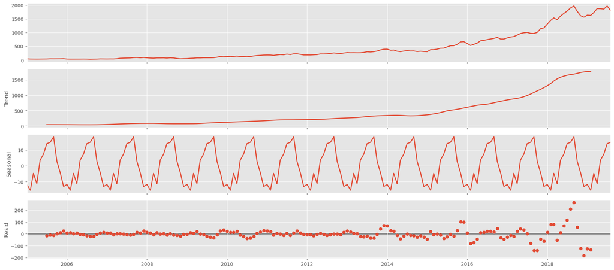

```python
my_decomposition_month = sm.tsa.seasonal_decompose(monthly_mean_close, model='additive')

plt.rcParams['figure.figsize'] = 18,8
plt.show()

fig = my_decomposition_month.plot()
```

See a nice repeated pattern. The seasonal pattern is same as we have additive model only.

Here observe a nice seasonal pattern. In the main notebook, we will see not such a nice pattern.

```python
monthly_mean_close = monthly_mean_close['Close']  # Replace with actual column name
month_stl = STL( monthly_mean_close )
month_stl_fit = month_stl.fit()
```

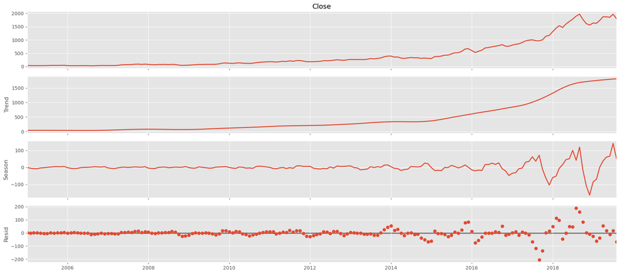

```python
fig = month_stl_fit.plot()
```

```python
df_stl_decomp = pd.DataFrame({'observed': month_stl_fit.observed,
                       'seasonal_adjusted': month_stl_fit.observed - month_stl_fit.seasonal,
                       'detrend': month_stl_fit.observed -month_stl_fit.trend},
                      index=monthly_mean_close.index)
```

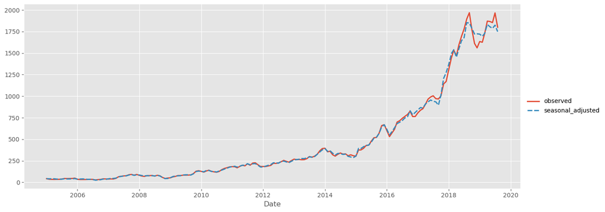

```python
sns.relplot( data = df_stl_decomp.loc[:, ['observed', 'seasonal_adjusted']],
            kind='line', aspect=2.5 )

plt.show()
```

Post 2016, the seasonal patterns start showing great effects. Prior 2016 we need to zoom on phases.

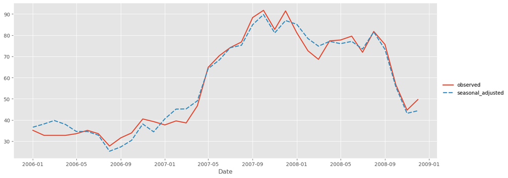

```python
df_filtered = df_stl_decomp.loc['2006-01-01':'2008-12-31', ['observed', 'seasonal_adjusted']]

# Plot using seaborn's relplot
sns.relplot(data=df_filtered, kind='line', aspect=2.5)

# Show the plot
plt.show()
```

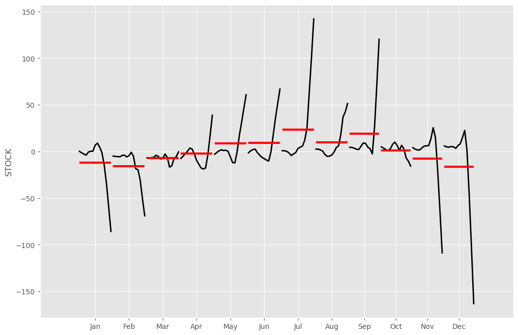

```python
df_stl_decomp['detrend_smooth'] = month_stl_fit.observed - (month_stl_fit.trend + month_stl_fit.resid)
fig, ax = plt.subplots(figsize=(12, 8))

sm.graphics.tsa.month_plot( df_stl_decomp.detrend_smooth, ylabel='STOCK', ax=ax )

plt.show()
```

Here in the detrended smoothing we can see that values are showing a great variation over the years. Hence, there is a huge difference in magnitude in close stock market. This implies that we should go with multiplicative model in stead of additive model.